# Classification of Denials

Steven P. Sanderson II, MPH

04 August, 2021

# 1 Business Understanding

In our example, the goal is to build a classification model to predict an account being denied by the insurance company or not. In particular, the model should learn from data and be able to predict whether account in a service line is going to be denied, given some predictor variables. Hence, we face a supervised learning situation and should use a classification model to predict the categorical outcomes (approved or denied). Furthermore, we use the F1-Score as a performance measure for our classification problem.

# 2 Data Understanding

In Data Understanding, you:

- Import data
- Clean data
- Format data properly
- Create new variables
- Get an overview about the complete data
- Split data into training and test set using stratified sampling
- Discover and visualize the data to gain insights

## 2.1 Import Data

First of all, let’s import the data:

```r
df_tbl <- healthyR_data %>%
    select(
      -mrn
      , -visit_id
      , -expected_length_of_stay
      , -length_of_stay_threshold
      , -readmit_expectation
      , -total_amount_due
    ) %>%
    rename(denial_flag = readmit_flag)
```

## 2.2 Clean data

To get a first impression of the data we take a look at the top 4 rows:

```r
df_tbl %>%
  slice_head(n = 4) %>%
  gt()
```

| visit_start_date_time | visit_end_date_time | total_charge_amount | total_adjustment_amount | payer_grouping | total_payment_amount | ip_op_flag | service_line | length_of_stay | los_outlier_flag | denial_flag |
| --- | --- | --- | --- | --- | --- | --- | --- | --- | --- | --- |
| 2010-01-04 05:00:00 | 2010-01-04 | 25983.88 | -20799.61 | Medicare B | -5184.27 | O | General Outpatient | 0 | 0 | 0 |
| 2010-01-04 05:00:00 | 2010-01-04 | 22774.05 | -12978.37 | Medicare HMO | -9795.68 | O | General Outpatient | 0 | 0 | 0 |
| 2010-01-04 05:00:00 | 2010-01-04 | 10690.45 | -7596.09 | HMO | -3094.36 | O | General Outpatient | 0 | 0 | 0 |
| 2010-01-04 05:00:00 | 2010-01-04 | 8788.02 | -7663.57 | Medicare B | -1124.45 | O | Colonoscopy/Endoscopy | 0 | 0 | 0 |

## 2.3 Format data

Next, we take a look at the data structure and check whether all data formats are correct:

Numeric variables should be formatted as integers (int) or double precision floating point numbers (dbl).

Categorical (nominal and ordinal) variables should usually be formatted as factors (fct) and not characters (chr). Especially, if they don’t have many levels.

```r
glimpse(df_tbl)
```

```
## Rows: 187,721
## Columns: 11
## $ visit_start_date_time   <dttm> 2010-01-04 05:00:00, 2010-01-04 05:00:00, 201~
## $ visit_end_date_time     <dttm> 2010-01-04, 2010-01-04, 2010-01-04, 2010-01-0~
## $ total_charge_amount     <dbl> 25983.88, 22774.05, 10690.45, 8788.02, 7325.17~
## $ total_adjustment_amount <dbl> -20799.61, -12978.37, -7596.09, -7663.57, -605~
## $ payer_grouping          <chr> "Medicare B", "Medicare HMO", "HMO", "Medicare~
## $ total_payment_amount    <dbl> -5184.27, -9795.68, -3094.36, -1124.45, -1269.~
## $ ip_op_flag              <chr> "O", "O", "O", "O", "O", "O", "O", "O", "O", "~
## $ service_line            <chr> "General Outpatient", "General Outpatient", "G~
## $ length_of_stay          <dbl> 0, 0, 0, 0, 0, 0, 0, 0, 0, 0, 0, 0, 0, 0, 0, 0~
## $ los_outlier_flag        <dbl> 0, 0, 0, 0, 0, 0, 0, 0, 0, 0, 0, 0, 0, 0, 0, 0~
## $ denial_flag             <dbl> 0, 0, 0, 0, 0, 0, 0, 0, 0, 0, 0, 0, 0, 0, 0, 0~
```

```r
df_fct_tbl <- df_tbl %>%
  mutate(across(where(is.character), as_factor)) %>%
  mutate(denial_flag = as_factor(denial_flag)) %>%
  mutate(los_outlier_flag = as_factor(los_outlier_flag)) %>%
  mutate(service_line = fct_lump_prop(service_line, prop = 0.015))
```

The package `DataExplorer` helps us to explore the data class structure visually:

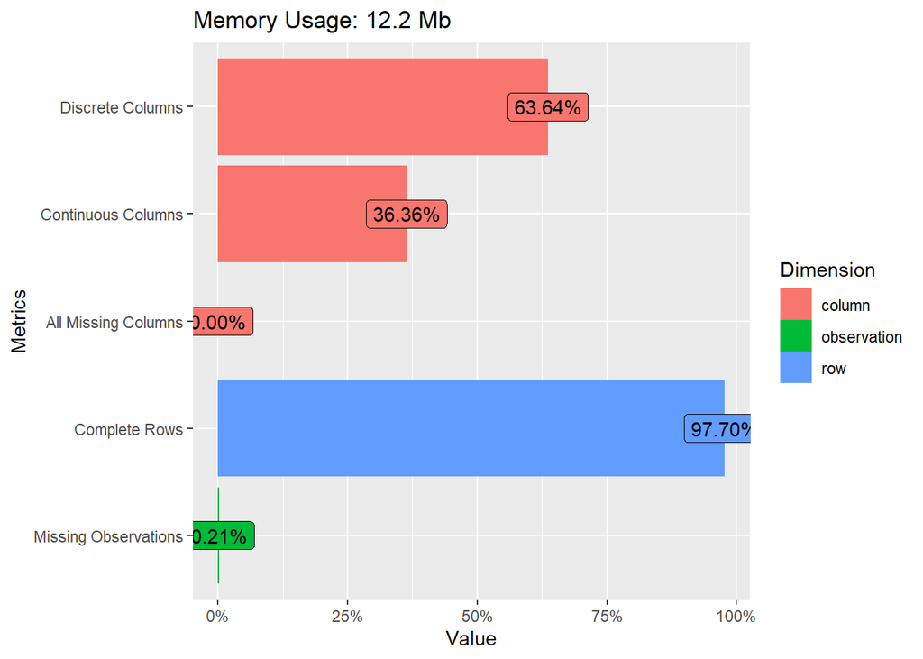

```r
#vis_dat(df_fct_tbl, warn_large_data = FALSE)

plot_intro(df_fct_tbl)
```

## 2.4 Missing data

Lets check on where the missing values are:

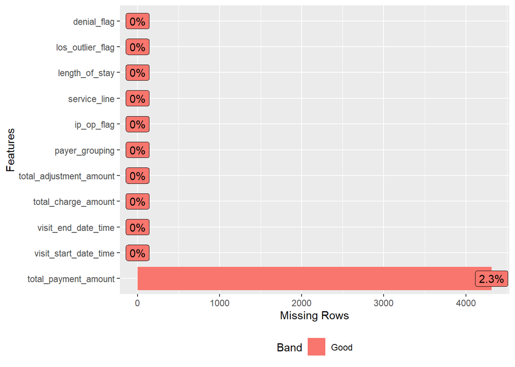

```r
plot_missing(df_fct_tbl)
```

So we see that the only column that has missing values is `total_payment_amount` from our experience we know that these can be imputed to $0.00.

```r
df_imp_tbl <- df_fct_tbl %>%
  mutate(total_payment_amount = ifelse(is.na(total_payment_amount), 0, total_payment_amount))
```

```r
df_imp_tbl %>%
  count(service_line, name = "total_visits")  %>%
  arrange(desc(total_visits)) %>%
  mutate(percent = round(total_visits / sum(total_visits) * 100, 2)) %>%
  mutate(cum_perc = cumsum(percent)) %>%
  gt() %>%
  cols_label(
    service_line   = "Service Line"
    , total_visits = "Visits"
    , percent      = "Percent %"
    , cum_perc     = "Cumulative %"
  ) %>%
  fmt_number(
    columns = c(total_visits),
    suffixing = TRUE
  ) %>%
  cols_align(align = "left", columns = c(service_line))
```

| Service Line | Visits | Percent % | Cumulative % |
| --- | --- | --- | --- |
| Medical | 64.44K | 34.32 | 34.32 |
| General Outpatient | 50.53K | 26.92 | 61.24 |
| Other | 23.66K | 12.60 | 73.84 |
| Surgical | 14.92K | 7.95 | 81.79 |
| Colonoscopy/Endoscopy | 11.49K | 6.12 | 87.91 |
| Cataract Removal | 4.93K | 2.63 | 90.54 |
| COPD | 4.40K | 2.34 | 92.88 |
| CHF | 3.87K | 2.06 | 94.94 |
| Pneumonia | 3.32K | 1.77 | 96.71 |
| Cellulitis | 3.31K | 1.76 | 98.47 |
| Major Depression/Bipolar Affective Disorders | 2.87K | 1.53 | 100.00 |

## 2.5 Data overview

```r
skim(df_imp_tbl)
```

Data summary

| Name | df_imp_tbl |
| --- | --- |
| Number of rows | 187721 |
| Number of columns | 11 |
| _______________________ |  |
| Column type frequency: |  |
| factor | 5 |
| numeric | 4 |
| POSIXct | 2 |
| ________________________ |  |
| Group variables | None |

**Variable type: factor**

| skim_variable | n_missing | complete_rate | ordered | n_unique | top_counts |
| --- | --- | --- | --- | --- | --- |
| payer_grouping | 0 | 1 | FALSE | 13 | Med: 52622, Med: 25484, Blu: 24357, Med: 22563 |
| ip_op_flag | 0 | 1 | FALSE | 2 | I: 117117, O: 70604 |
| service_line | 0 | 1 | FALSE | 11 | Med: 64435, Gen: 50526, Oth: 23659, Sur: 14916 |
| los_outlier_flag | 0 | 1 | FALSE | 2 | 0: 187449, 1: 272 |
| denial_flag | 0 | 1 | FALSE | 2 | 0: 173288, 1: 14433 |

**Variable type: numeric**

| skim_variable | n_missing | complete_rate | mean | sd | p0 | p25 | p50 | p75 | p100 | hist |
| --- | --- | --- | --- | --- | --- | --- | --- | --- | --- | --- |
| total_charge_amount | 0 | 1 | 44707.73 | 63201.19 | 0.13 | 12128.04 | 27585.68 | 53682.67 | 3686443.50 | ▇▁▁▁▁ |
| total_adjustment_amount | 0 | 1 | -38519.15 | 58546.91 | -3059344.26 | -46915.76 | -21474.96 | -8995.37 | 87590.13 | ▁▁▁▁▇ |
| total_payment_amount | 0 | 1 | -8482.54 | 12462.68 | -627099.24 | -10392.48 | -5728.59 | -2277.86 | 1629.69 | ▁▁▁▁▇ |
| length_of_stay | 0 | 1 | 3.87 | 7.18 | 0.00 | 0.00 | 2.00 | 5.00 | 422.00 | ▇▁▁▁▁ |

**Variable type: POSIXct**

| skim_variable | n_missing | complete_rate | min | max | median | n_unique |
| --- | --- | --- | --- | --- | --- | --- |
| visit_start_date_time | 0 | 1 | 2010-01-04 05:00:00 | 2020-11-12 05:00:00 | 2015-07-14 01:11:00 | 133383 |
| visit_end_date_time | 0 | 1 | 2010-01-04 00:00:00 | 2020-11-12 00:00:00 | 2015-07-17 12:14:00 | 115897 |

## 2.5 Data splitting

Now lets take a look at the class balance:

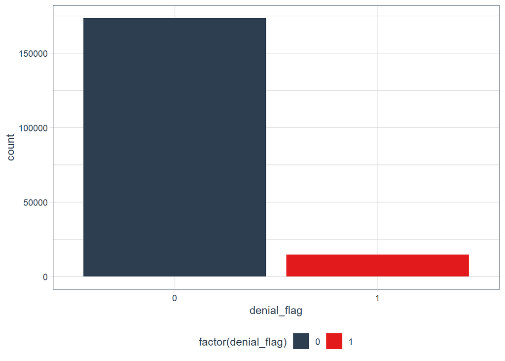

```r
df_imp_tbl %>%
  ggplot(aes(denial_flag, fill = factor(denial_flag))) +
  geom_bar() +
  theme_tq() +
  scale_fill_tq()
```

We can see that the variable we are trying to predict (denial_flag) is severly imbalanced. This will cause problems when trying to make predictions on this variable so we must even out the sampling. We can do this with the `ROSE` algorithm.

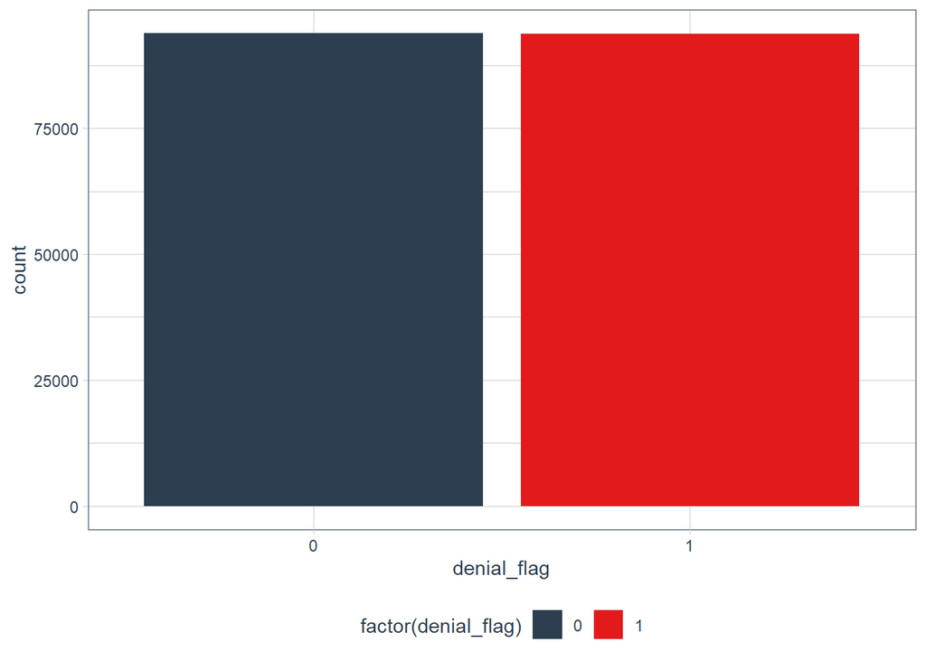

```r
df_balanced_tbl <- ovun.sample(
  denial_flag ~.
  , data = df_imp_tbl
)$data

df_balanced_tbl %>%
  ggplot(aes(denial_flag, fill = factor(denial_flag))) +
  geom_bar() +
  theme_tq() +
  scale_fill_tq()
```

Now lets create our splits object and our training and testing data sets.

```r
# Fix the random numbers by setting the seed
# This enables the analysis to be reproducible
set.seed(123)

# Put 80% of the data into the training set
data_split <- initial_split(df_balanced_tbl,
                           prop = 0.8,
                           strata = denial_flag)

# Create dataframes for the two sets:
train_data <- training(data_split)
test_data  <- testing(data_split)
```

## 2.8 Data Exploration

The point of data exploration is to gain insights that will help you select important variables for your model and to get ideas for feature engineering in the data preparation phase. Usually, data exploration is an iterative process: once you get a prototype model up and running, you can analyze its output to gain more insights and come back to this exploration step. It is important to note that we perform data exploration only with our training data.

### 2.8.1 Create copy of training data

```r
train_tbl <- train_data
```

Lets create a function that will pass in predictors and give us boxplots back.

```r
print_boxplot <- function(.y_var){

  # convert strings to variable
  y_var <- sym(.y_var)

  # unquote variables using {{}}
  train_tbl %>%
  ggplot(
    aes(
      x = denial_flag
      , y = {{y_var}}
      , fill = denial_flag
      , color = denial_flag
      )
    ) +
  geom_boxplot(alpha=0.4)

}
```

### 2.8.2 Obtain Numeric Vars

Obtain all the names we want for our plots:

```r
y_var <-  train_tbl %>%
  select(where(is.numeric)) %>%
  variable.names()
```

View plots:

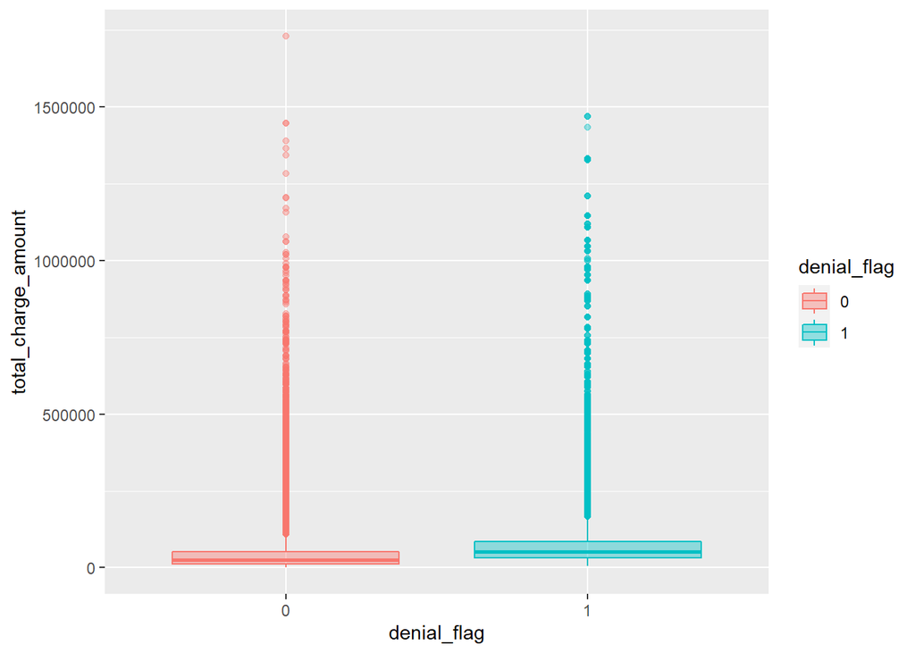

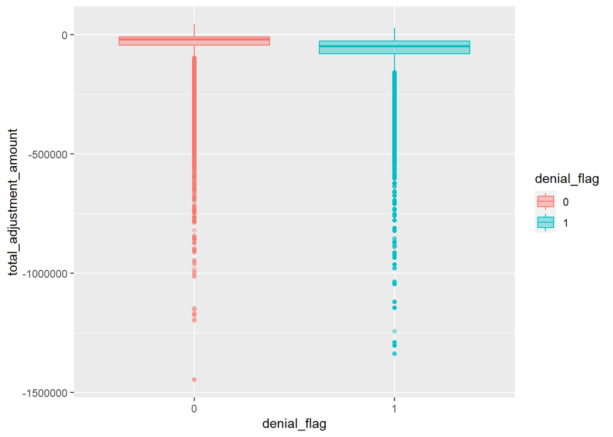

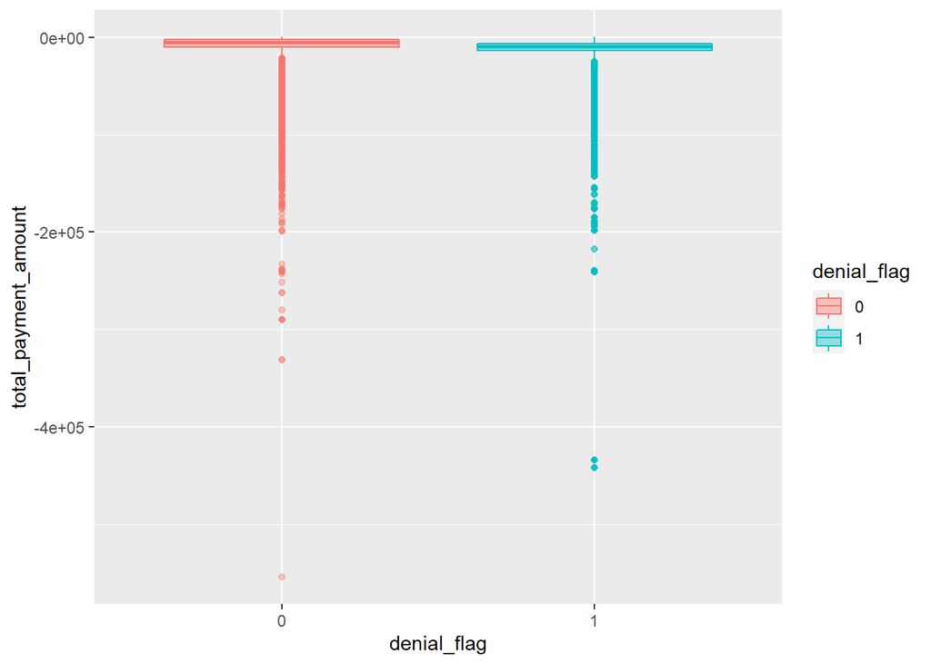

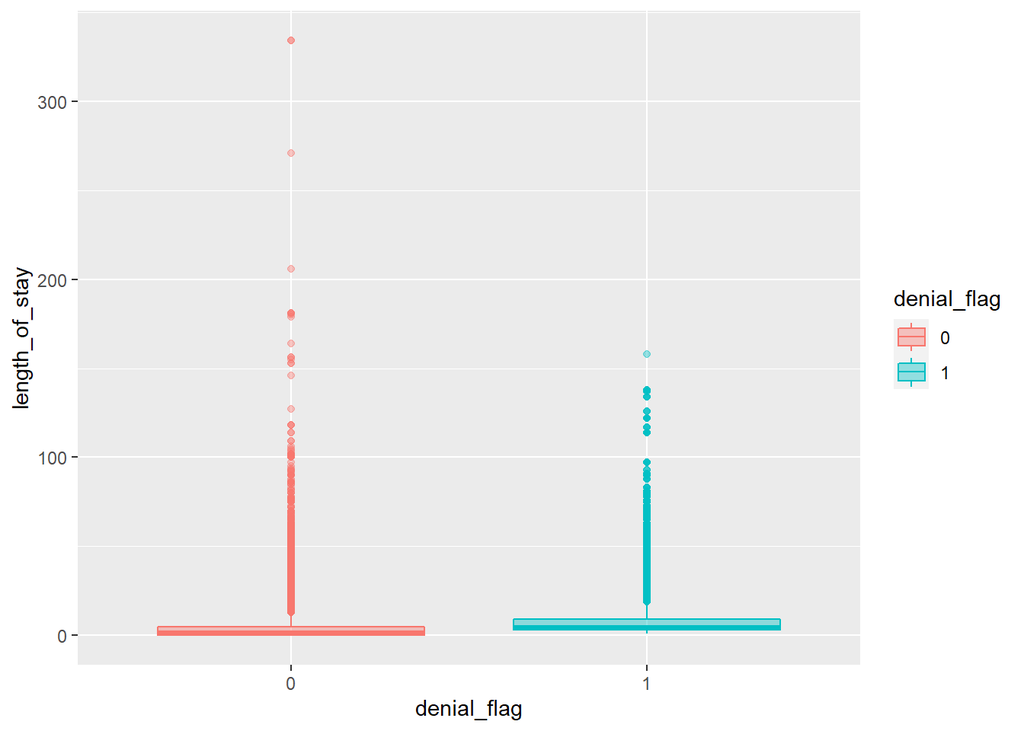

```r
map(y_var, print_boxplot)
```

The function geom_bin2d() creates a heatmap by counting the number of cases in each group, and then mapping the number of cases to each subgroub’s fill. Lets check them out.

```r
print_categorical_heatmap <- function(.y_var){

  # convert strings to variable
  y_var <- sym(.y_var)

  # unquote variables using {{}}
  train_tbl %>%
    ggplot(
      aes(
        x = denial_flag
        , y = {{y_var}}
      )
    ) +
    geom_bin2d() +
    scale_fill_continuous(type = "viridis") +
    theme_tq()

}
```

```r
y_vars <- train_tbl %>%
  select(where(is.factor), -denial_flag) %>%
  variable.names()
```

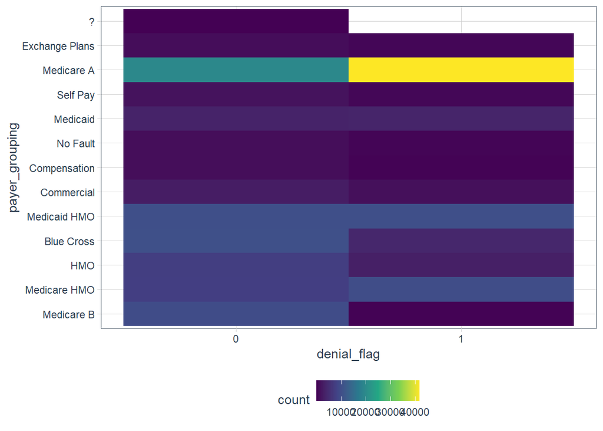

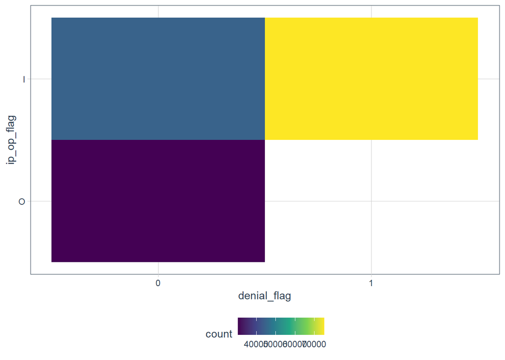

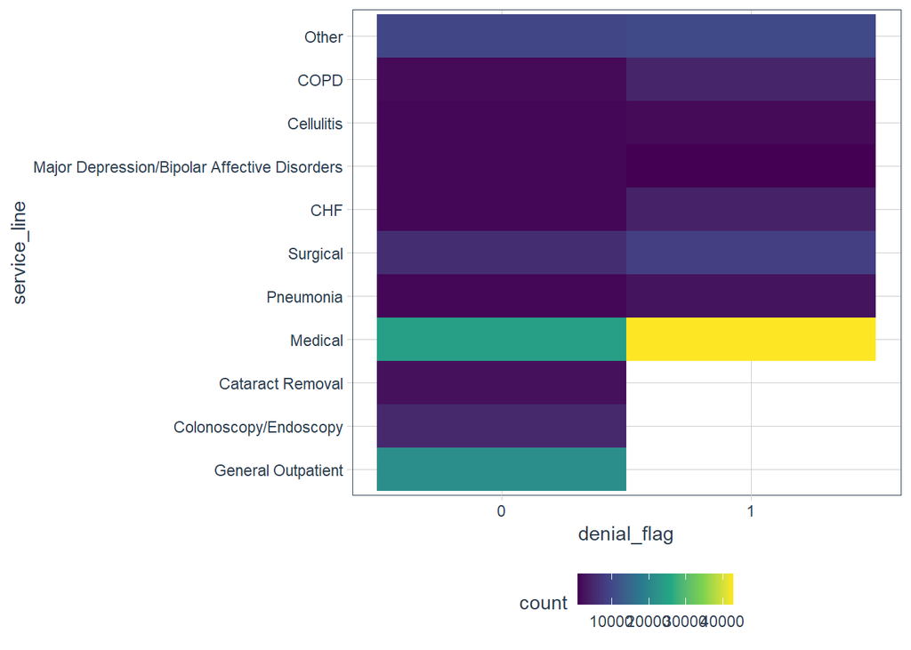

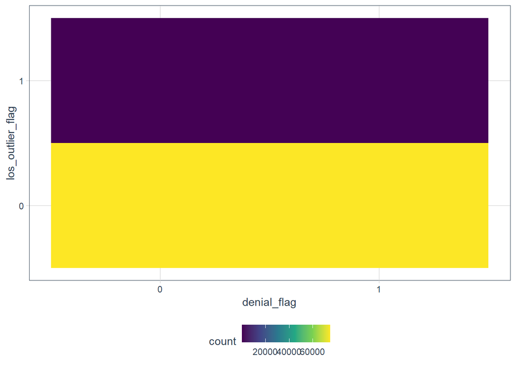

```r
map(y_vars, print_categorical_heatmap)
```

# 3 Data Preperation

Data preparation:

- Handle missing values
- Fix or remove outliers
- Feature selection
- Feature engineering
- Feature scaling
- Create a validation set

Next, we’ll preprocess our data before training the models. We mainly use the tidymodels packages recipes and workflows for this steps. Recipes are built as a series of optional data preparation steps, such as:

Data cleaning: Fix or remove outliers, fill in missing values (e.g., with zero, mean, median…) or drop their rows (or columns).

Feature selection: Drop the attributes that provide no useful information for the task.

Feature engineering: Discretize continuous features, decompose features (e.g., the weekday from a date variable, etc.), add promising transformations of features (e.g., log(x), sqrt(x), x2 , etc.) or aggregate features into promising new features (like we already did).

Feature scaling: Standardize or normalize features.

We will want to use our recipe across several steps as we train and test our models. To simplify this process, we can use a model workflow, which pairs a model and recipe together.

## 3.1 Data preparation

We have already created our `splits` object `data_split`

```r
data_split
```

```
## <Analysis/Assess/Total>
## <150176/37545/187721>
```

## 3.2 Data prepropecessing recipe

The type of data preprocessing is dependent on the data and the type of model being fit. The excellent book “Tidy Modeling with R” provides an appendix with recommendations for baseline levels of preprocessing that are needed for various model functions.

Let’s create a base recipe for all of our classification models. Note that the sequence of steps matter:

Note that instead of deleting missing values we could also easily substitute (i.e., impute) missing values of variables by one of the following methods (using the training set):

- median
- mean
- mode
- k-nearest neighbors
- linear model
- bagged tree models

Take a look at the recipes reference for an overview about all possible imputation methods.

Note that this step may cause problems if your categorical variable has too many levels - especially if some of the levels are very infrequent. In this case you should either drop the variable or pool infrequently occurring values into an “other” category with step_other. This steps has to be performed before step_dummy.

- step_zv(): removes any numeric variables that have zero variance.
- step_corr(): will remove predictor variables that have large correlations with other predictor variables.

We have already used the `ROSE` package to create a balanced data set and used that to make our splits so we can go ahead and create our recipe now.

```r
denial_rec <- recipe(
  denial_flag ~ .,
  data = train_data
)%>%
  step_log(total_charge_amount) %>%
  step_naomit(everything(), skip = TRUE) %>%
  step_novel(all_nominal(), -all_outcomes()) %>%
  step_normalize(all_numeric(), -all_outcomes()) %>%
  step_dummy(all_nominal(), -all_outcomes()) %>%
  step_zv(all_numeric(), -all_outcomes()) %>%
  step_corr(all_numeric_predictors(), threshold = 0.7, method = "spearman")
```

```r
summary(denial_rec)
```

```
## # A tibble: 11 x 4
##    variable                type    role      source
##    <chr>                   <chr>   <chr>     <chr>
##  1 visit_start_date_time   date    predictor original
##  2 visit_end_date_time     date    predictor original
##  3 total_charge_amount     numeric predictor original
##  4 total_adjustment_amount numeric predictor original
##  5 payer_grouping          nominal predictor original
##  6 total_payment_amount    numeric predictor original
##  7 ip_op_flag              nominal predictor original
##  8 service_line            nominal predictor original
##  9 length_of_stay          numeric predictor original
## 10 los_outlier_flag        nominal predictor original
## 11 denial_flag             nominal outcome   original
```

If we would like to check if all of our preprocessing steps from above actually worked, we can proceed as follows:

```r
prepped_data <-
  denial_rec %>% # use the recipe object
  prep() %>%     # perform the recipe on training data
  juice()        # extract only the pre-processed data.frame

prepped_data %>% glimpse()
```

```
## Rows: 150,176
## Columns: 28
## $ visit_start_date_time                                     <dttm> 2017-01-03 ~
## $ visit_end_date_time                                       <dttm> 2017-01-05 ~
## $ total_payment_amount                                      <dbl> -0.3050476, ~
## $ denial_flag                                               <fct> 0, 0, 0, 0, ~
## $ payer_grouping_Medicare.HMO                               <dbl> 0, 0, 0, 0, ~
## $ payer_grouping_HMO                                        <dbl> 0, 0, 1, 0, ~
## $ payer_grouping_Blue.Cross                                 <dbl> 1, 0, 0, 1, ~
## $ payer_grouping_Medicaid.HMO                               <dbl> 0, 0, 0, 0, ~
## $ payer_grouping_Commercial                                 <dbl> 0, 0, 0, 0, ~
## $ payer_grouping_Compensation                               <dbl> 0, 0, 0, 0, ~
## $ payer_grouping_No.Fault                                   <dbl> 0, 0, 0, 0, ~
## $ payer_grouping_Medicaid                                   <dbl> 0, 0, 0, 0, ~
## $ payer_grouping_Self.Pay                                   <dbl> 0, 0, 0, 0, ~
## $ payer_grouping_Medicare.A                                 <dbl> 0, 1, 0, 0, ~
## $ payer_grouping_Exchange.Plans                             <dbl> 0, 0, 0, 0, ~
## $ payer_grouping_X.                                         <dbl> 0, 0, 0, 0, ~
## $ ip_op_flag_I                                              <dbl> 1, 1, 1, 0, ~
## $ service_line_Colonoscopy.Endoscopy                        <dbl> 0, 0, 0, 0, ~
## $ service_line_Cataract.Removal                             <dbl> 0, 0, 0, 0, ~
## $ service_line_Medical                                      <dbl> 1, 0, 1, 0, ~
## $ service_line_Pneumonia                                    <dbl> 0, 0, 0, 0, ~
## $ service_line_Surgical                                     <dbl> 0, 0, 0, 0, ~
## $ service_line_CHF                                          <dbl> 0, 0, 0, 0, ~
## $ service_line_Major.Depression.Bipolar.Affective.Disorders <dbl> 0, 0, 0, 0, ~
## $ service_line_Cellulitis                                   <dbl> 0, 0, 0, 0, ~
## $ service_line_COPD                                         <dbl> 0, 0, 0, 0, ~
## $ service_line_Other                                        <dbl> 0, 1, 0, 0, ~
## $ los_outlier_flag_X1                                       <dbl> 0, 0, 0, 0, ~
```

## 3.3 Validation set

Remember that we already partitioned our data set into a training set and test set. This lets us judge whether a given model will generalize well to new data. However, using only two partitions may be insufficient when doing many rounds of hyper-parameter tuning (which we don’t perform in this tutorial but it is always recommended to use a validation set).

Therefore, it is usually a good idea to create a so called validation set. We use k-fold crossvalidation to build a set of 5 validation folds with the function vfold_cv. We also use stratified sampling:

```r
set.seed(100)

cv_folds <- vfold_cv(
  train_data,
  v      = 5,
  strata = denial_flag
  )
```

# 4 Model building

## 4.1 Specify models

The process of specifying our models is always as follows:

- Pick a model type
- Set the engine
- Set the mode: regression or classification

### 4.1.1 Logistic regression

```r
log_spec <- # your model specification
  logistic_reg() %>%  # model type
  set_engine(engine = "glm") %>%  # model engine
  set_mode("classification") # model mode

# Show your model specification
log_spec
```

```
## Logistic Regression Model Specification (classification)
##
## Computational engine: glm
```

### 4.1.2 Random forest

Random Forest from the ranger package

```r
rf_spec <-
  rand_forest() %>%
  set_engine("ranger", importance = "impurity") %>%
  set_mode("classification")
```

When we set the engine, we add importance = “impurity”. This will provide variable importance scores for this model, which gives some insight into which predictors drive model performance.

## 4.2 Create workflows

To combine the data preparation recipe with the model building, we use the package workflows. A workflow is an object that can bundle together your pre-processing recipe, modeling, and even post-processing requests (like calculating the RMSE).

### 4.2.1 Logistic regression

Bundle recipe and model with workflows:

```r
log_wflow <- # new workflow object
 workflow() %>% # use workflow function
 add_recipe(denial_rec) %>%   # use the new recipe
 add_model(log_spec)   # add your model spec

# show object
log_wflow
```

```
## == Workflow ====================================================================
## Preprocessor: Recipe
## Model: logistic_reg()
##
## -- Preprocessor ----------------------------------------------------------------
## 7 Recipe Steps
##
## * step_log()
## * step_naomit()
## * step_novel()
## * step_normalize()
## * step_dummy()
## * step_zv()
## * step_corr()
##
## -- Model -----------------------------------------------------------------------
## Logistic Regression Model Specification (classification)
##
## Computational engine: glm
```

###4.2.2 Random forest

Bundle recipe and model:

```r
rf_wflow <-
 workflow() %>%
 add_recipe(denial_rec) %>%
 add_model(rf_spec)
```

## 4.3 Evaluate models

Now we can use our validation set (cv_folds) to estimate the performance of our models using the fit_resamples() function to fit the models on each of the folds and store the results.

Note that fit_resamples() will fit our model to each resample and evaluate on the heldout set from each resample. The function is usually only used for computing performance metrics across some set of resamples to evaluate our models (like accuracy) - the models are not even stored. However, in our example we save the predictions in order to visualize the model fit and residuals with control_resamples(save_pred = TRUE).

Finally, we collect the performance metrics with collect_metrics() and pick the model that does best on the validation set.

### 4.3.1 Logistic regression

We use our workflow object to perform resampling. Furthermore, we use metric_set()to choose some common classification performance metrics provided by the yardstick package. Visit yardsticks reference to see the complete list of all possible metrics.

Note that Cohen’s kappa coefficient (κ) is a similar measure to accuracy, but is normalized by the accuracy that would be expected by chance alone and is very useful when one or more classes have large frequency distributions. The higher the value, the better.

```r
log_res <-
  log_wflow %>%
  fit_resamples(
    resamples = cv_folds,
    metrics = metric_set(
      recall, precision, f_meas,
      accuracy, kap, roc_auc
      , sens, spec
    ),
    control = control_resamples(
      save_pred = TRUE)
    )
```

#### 4.3.1.1 Model coefficients

The above described method to obtain log_res is fine if we are not interested in model coefficients. However, if we would like to extract the model coeffcients from fit_resamples, we need to proceed as follows:

**save model coefficients for a fitted model object from a workflow**

```r
get_model <- function(x) {
  pull_workflow_fit(x) %>% tidy()
}

# same as before with one exception
log_res_2 <-
  log_wflow %>%
  fit_resamples(
    resamples = cv_folds,
    metrics = metric_set(
      recall, precision, f_meas,
      accuracy, kap,
      roc_auc, sens, spec),
    control = control_resamples(
      save_pred = TRUE,
      extract = get_model) # use extract and our new function
    )
```

Now there is a `.extracts` column with nested tibbles.

```r
log_res_2$.extracts[[1]]
```

```
## # A tibble: 1 x 2
##   .extracts         .config
##   <list>            <chr>
## 1 <tibble [28 x 5]> Preprocessor1_Model1
```

```r
log_res_2$.extracts[[1]][[1]]
```

```
## [[1]]
## # A tibble: 28 x 5
##    term                             estimate     std.error statistic   p.value
##    <chr>                               <dbl>         <dbl>     <dbl>     <dbl>
##  1 (Intercept)                 -31.1         96.5             -0.323 7.47e-  1
##  2 visit_start_date_time        -0.000000352  0.0000000150   -23.5   7.71e-122
##  3 visit_end_date_time           0.000000351  0.0000000150    23.4   4.50e-121
##  4 total_payment_amount         -0.0388       0.00971         -4.00  6.37e-  5
##  5 payer_grouping_Medicare.HMO   0.526        0.141            3.74  1.85e-  4
##  6 payer_grouping_HMO           -0.129        0.142           -0.903 3.66e-  1
##  7 payer_grouping_Blue.Cross    -0.103        0.142           -0.724 4.69e-  1
##  8 payer_grouping_Medicaid.HMO   0.542        0.141            3.85  1.17e-  4
##  9 payer_grouping_Commercial    -0.123        0.147           -0.841 4.01e-  1
## 10 payer_grouping_Compensation  -0.418        0.170           -2.46  1.39e-  2
## # ... with 18 more rows
```

```r
all_coef <- map_dfr(log_res_2$.extracts, ~ .x[[1]][[1]])

all_coef
```

```
## # A tibble: 139 x 5
##    term                             estimate     std.error statistic   p.value
##    <chr>                               <dbl>         <dbl>     <dbl>     <dbl>
##  1 (Intercept)                 -31.1         96.5             -0.323 7.47e-  1
##  2 visit_start_date_time        -0.000000352  0.0000000150   -23.5   7.71e-122
##  3 visit_end_date_time           0.000000351  0.0000000150    23.4   4.50e-121
##  4 total_payment_amount         -0.0388       0.00971         -4.00  6.37e-  5
##  5 payer_grouping_Medicare.HMO   0.526        0.141            3.74  1.85e-  4
##  6 payer_grouping_HMO           -0.129        0.142           -0.903 3.66e-  1
##  7 payer_grouping_Blue.Cross    -0.103        0.142           -0.724 4.69e-  1
##  8 payer_grouping_Medicaid.HMO   0.542        0.141            3.85  1.17e-  4
##  9 payer_grouping_Commercial    -0.123        0.147           -0.841 4.01e-  1
## 10 payer_grouping_Compensation  -0.418        0.170           -2.46  1.39e-  2
## # ... with 129 more rows
```

#### 4.3.1.2 Performance metrics

Show average performance over all folds (note that we use log_res):

```r
log_res %>%  collect_metrics(summarize = TRUE)
```

```
## # A tibble: 8 x 6
##   .metric   .estimator  mean     n std_err .config
##   <chr>     <chr>      <dbl> <int>   <dbl> <chr>
## 1 accuracy  binary     0.725     5 0.00131 Preprocessor1_Model1
## 2 f_meas    binary     0.664     5 0.00173 Preprocessor1_Model1
## 3 kap       binary     0.451     5 0.00262 Preprocessor1_Model1
## 4 precision binary     0.855     5 0.00300 Preprocessor1_Model1
## 5 recall    binary     0.543     5 0.00222 Preprocessor1_Model1
## 6 roc_auc   binary     0.783     5 0.00182 Preprocessor1_Model1
## 7 sens      binary     0.543     5 0.00222 Preprocessor1_Model1
## 8 spec      binary     0.908     5 0.00232 Preprocessor1_Model1
```

Show performance for every single fold:

```r
log_res %>%  collect_metrics(summarize = FALSE)
```

```
## # A tibble: 40 x 5
##    id    .metric   .estimator .estimate .config
##    <chr> <chr>     <chr>          <dbl> <chr>
##  1 Fold1 recall    binary         0.539 Preprocessor1_Model1
##  2 Fold1 precision binary         0.859 Preprocessor1_Model1
##  3 Fold1 f_meas    binary         0.662 Preprocessor1_Model1
##  4 Fold1 accuracy  binary         0.725 Preprocessor1_Model1
##  5 Fold1 kap       binary         0.451 Preprocessor1_Model1
##  6 Fold1 sens      binary         0.539 Preprocessor1_Model1
##  7 Fold1 spec      binary         0.912 Preprocessor1_Model1
##  8 Fold1 roc_auc   binary         0.781 Preprocessor1_Model1
##  9 Fold2 recall    binary         0.542 Preprocessor1_Model1
## 10 Fold2 precision binary         0.854 Preprocessor1_Model1
## # ... with 30 more rows
```

#### 4.3.1.3 Collect predictions

To obtain the actual model predictions, we use the function collect_predictions and save the result as log_pred:

```r
log_pred <-
  log_res %>%
  collect_predictions()
```

#### 4.3.1.4 Confusion matrix

Now we can use the predictions to create a confusion matrix with conf_mat():

```r
log_pred %>%
  conf_mat(denial_flag, .pred_class)
```

```
##           Truth
## Prediction     0     1
##          0 40763  6895
##          1 34330 68188
```

Additionally, the confusion matrix can quickly be visualized in different formats using autoplot(). Type mosaic:

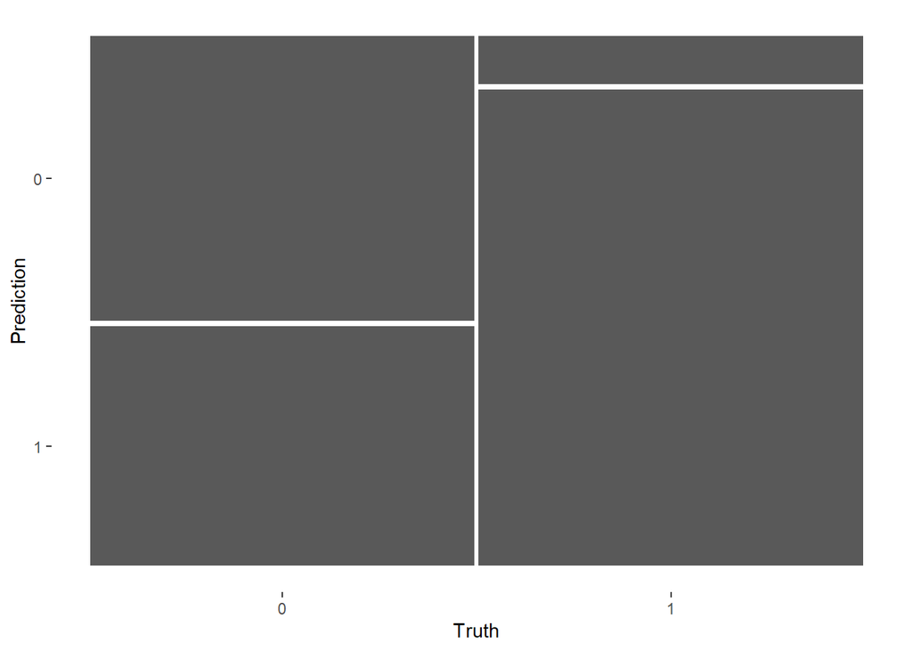

```r
log_pred %>%
  conf_mat(denial_flag, .pred_class) %>%
  autoplot(type = "mosaic")
```

Or type heatmap:

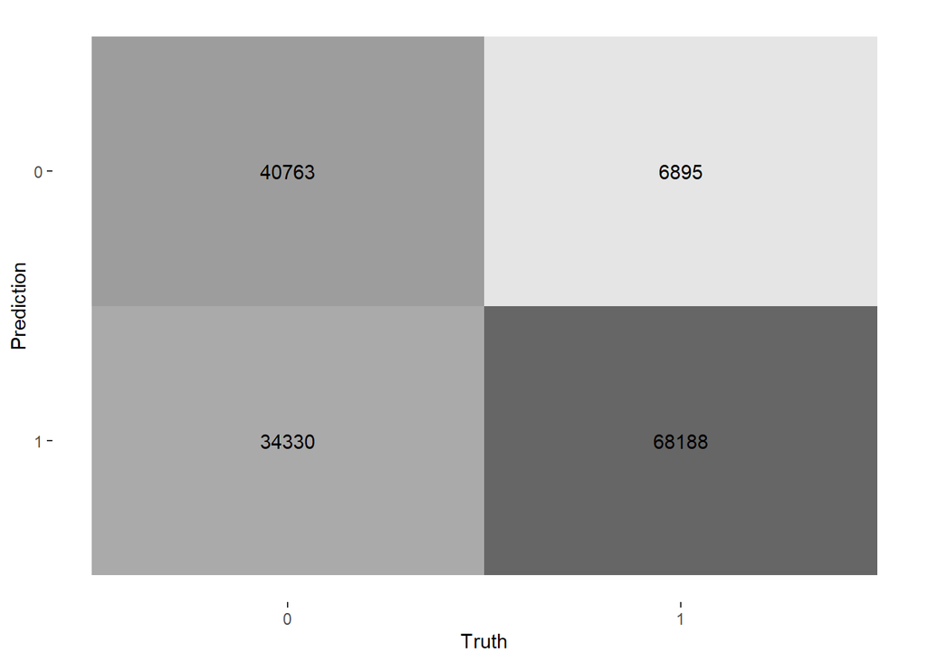

```r
log_pred %>%
  conf_mat(denial_flag, .pred_class) %>%
  autoplot(type = "heatmap")
```

#### 4.3.1.5 ROC-Curve

We can also make an ROC curve for our 5 folds. Since the category we are predicting is the first level in the denial_flag factor (“0 - not_denied”), we provide roc_curve() with the relevant class probability .pred_0:

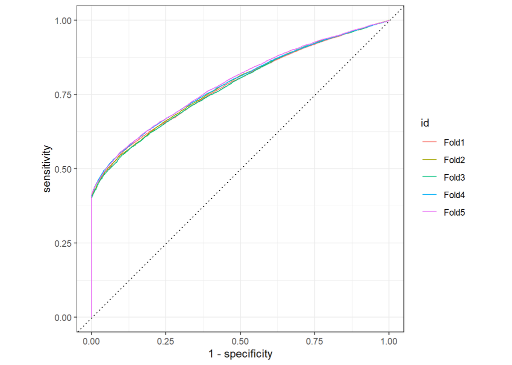

```r
log_pred %>%
  group_by(id) %>% # id contains our folds
  roc_curve(denial_flag, .pred_0) %>%
  autoplot()
```

#### 4.3.1.6 Probability distributions

Plot predicted probability distributions for our two classes.

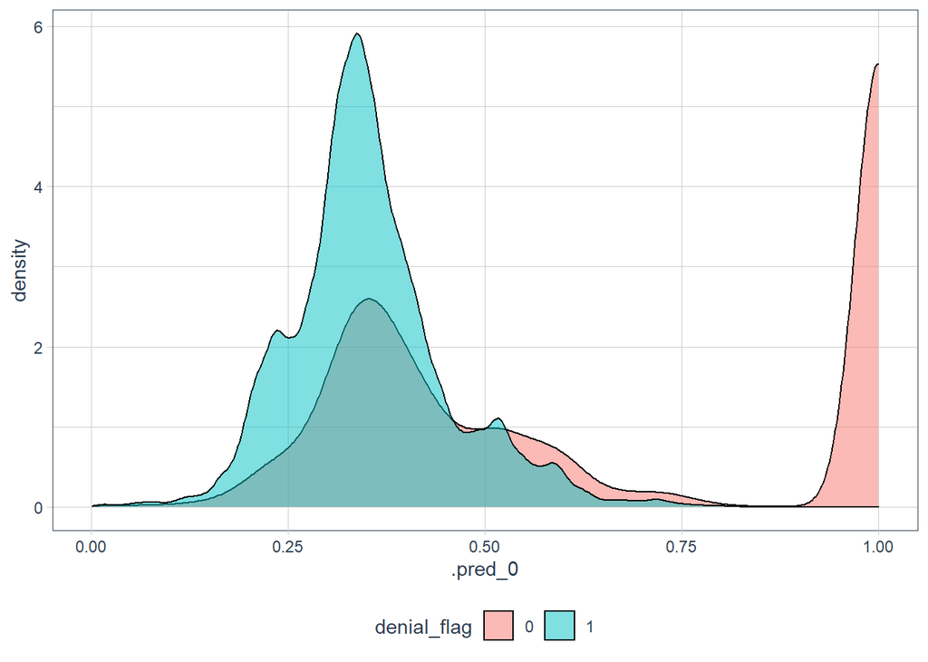

```r
log_pred %>%
  ggplot() +
  geom_density(
    aes(
      x = .pred_0
      , fill = denial_flag)
    , alpha = 0.5
  ) +
  theme_tq()
```

### 4.3.2 Random forest

We don’t repeat all of the steps shown in logistic regression and just focus on the performance metrics.

```r
rf_res <-
  rf_wflow %>%
  fit_resamples(
    resamples = cv_folds,
    metrics = metric_set(
      recall, precision, f_meas,
      accuracy, kap,
      roc_auc, sens, spec),
    control = control_resamples(save_pred = TRUE)
    )

rf_res %>%  collect_metrics(summarize = TRUE)
```

```
## # A tibble: 8 x 6
##   .metric   .estimator  mean     n  std_err .config
##   <chr>     <chr>      <dbl> <int>    <dbl> <chr>
## 1 accuracy  binary     0.753     5 0.000997 Preprocessor1_Model1
## 2 f_meas    binary     0.692     5 0.00167  Preprocessor1_Model1
## 3 kap       binary     0.506     5 0.00199  Preprocessor1_Model1
## 4 precision binary     0.921     5 0.00182  Preprocessor1_Model1
## 5 recall    binary     0.554     5 0.00231  Preprocessor1_Model1
## 6 roc_auc   binary     0.821     5 0.00149  Preprocessor1_Model1
## 7 sens      binary     0.554     5 0.00231  Preprocessor1_Model1
## 8 spec      binary     0.952     5 0.00128  Preprocessor1_Model1
```

### 4.3.3 Compare models

Extract metrics from our models to compare them:

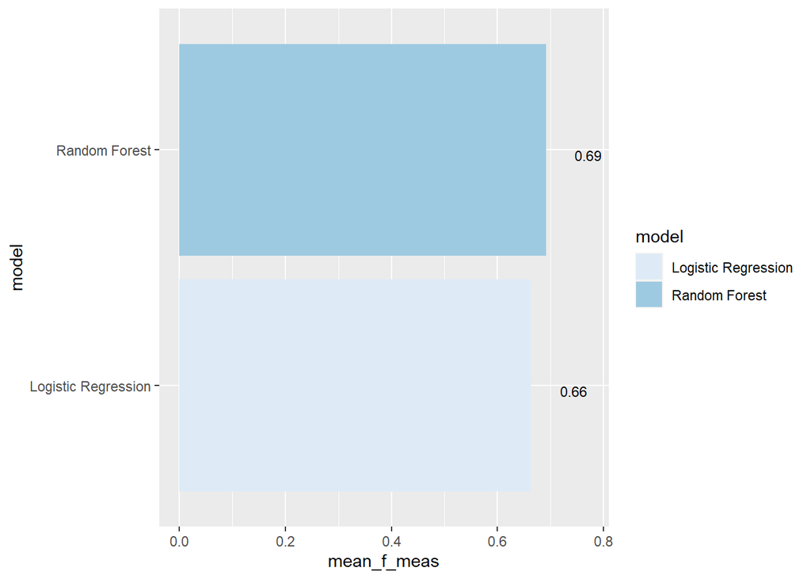

```r
log_metrics <-
  log_res %>%
  collect_metrics(summarise = TRUE) %>%
  mutate(model = "Logistic Regression") # add the name of the model to every row

rf_metrics <-
  rf_res %>%
  collect_metrics(summarise = TRUE) %>%
  mutate(model = "Random Forest")

# create dataframe with all models
model_compare <- bind_rows(log_metrics, rf_metrics)

# change data structure
model_comp <-
  model_compare %>%
  select(model, .metric, mean, std_err) %>%
  pivot_wider(names_from = .metric, values_from = c(mean, std_err))

# show mean F1-Score for every model
model_comp %>%
  arrange(mean_f_meas) %>%
  mutate(model = fct_reorder(model, mean_f_meas)) %>% # order results
  ggplot(aes(model, mean_f_meas, fill = model)) +
  geom_col() +
  coord_flip() +
  scale_fill_brewer(palette = "Blues") +
  geom_text(size = 3,
            aes(label = round(mean_f_meas, 2), y = mean_f_meas + 0.08),
            vjust = 1)
```

Show mean area under the curve (auc) per model

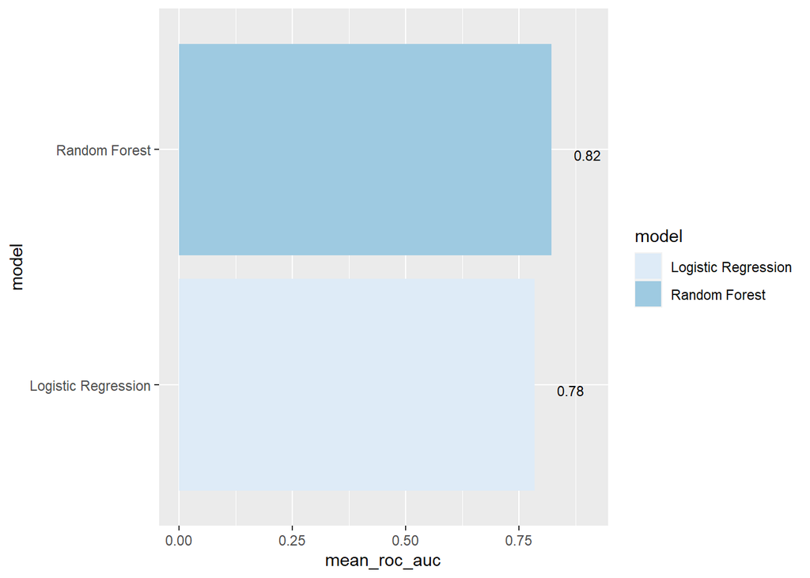

```r
model_comp %>%
  arrange(mean_roc_auc) %>%
  mutate(model = fct_reorder(model, mean_roc_auc)) %>%
  ggplot(aes(model, mean_roc_auc, fill=model)) +
  geom_col() +
  coord_flip() +
  scale_fill_brewer(palette = "Blues") +
     geom_text(
     size = 3,
     aes(label = round(mean_roc_auc, 2), y = mean_roc_auc + 0.08),
     vjust = 1
  )
```

Select the best model

```r
model_comp %>% slice_max(mean_f_meas)
```

```
## # A tibble: 1 x 17
##   model         mean_accuracy mean_f_meas mean_kap mean_precision mean_recall
##   <chr>                 <dbl>       <dbl>    <dbl>          <dbl>       <dbl>
## 1 Random Forest         0.753       0.692    0.506          0.921       0.554
## # ... with 11 more variables: mean_roc_auc <dbl>, mean_sens <dbl>,
## #   mean_spec <dbl>, std_err_accuracy <dbl>, std_err_f_meas <dbl>,
## #   std_err_kap <dbl>, std_err_precision <dbl>, std_err_recall <dbl>,
## #   std_err_roc_auc <dbl>, std_err_sens <dbl>, std_err_spec <dbl>
```

Now it’s time to fit the best model one last time to the full training set and evaluate the resulting final model on the test set.

## 4.4 Last evaluation on test set

Tidymodels provides the function last_fit() which fits a model to the whole training data and evaluates it on the test set. We just need to provide the workflow object of the best model as well as the data split object (not the training data).

```r
last_fit_rf <- last_fit(rf_wflow,
                        split = data_split,
                        metrics = metric_set(
                          recall, precision, f_meas,
                          accuracy, kap,
                          roc_auc, sens, spec)
                        )
```

Show performance metrics

```r
last_fit_rf %>%
  collect_metrics()
```

```
## # A tibble: 8 x 4
##   .metric   .estimator .estimate .config
##   <chr>     <chr>          <dbl> <chr>
## 1 recall    binary         0.551 Preprocessor1_Model1
## 2 precision binary         0.925 Preprocessor1_Model1
## 3 f_meas    binary         0.690 Preprocessor1_Model1
## 4 accuracy  binary         0.753 Preprocessor1_Model1
## 5 kap       binary         0.506 Preprocessor1_Model1
## 6 sens      binary         0.551 Preprocessor1_Model1
## 7 spec      binary         0.955 Preprocessor1_Model1
## 8 roc_auc   binary         0.824 Preprocessor1_Model1
```

And these are our final performance metrics. Remember that if a model fit to the training dataset also fits the test dataset well, minimal overfitting has taken place. This seems to be also the case in our example.

To learn more about the model we can access the variable importance scores via the .workflow column. We first need to pluck out the first element in the workflow column, then pull out the fit from the workflow object. Finally, the vip package helps us visualize the variable importance scores for the top features. Note that we can’t create this type of plot for every model engine.

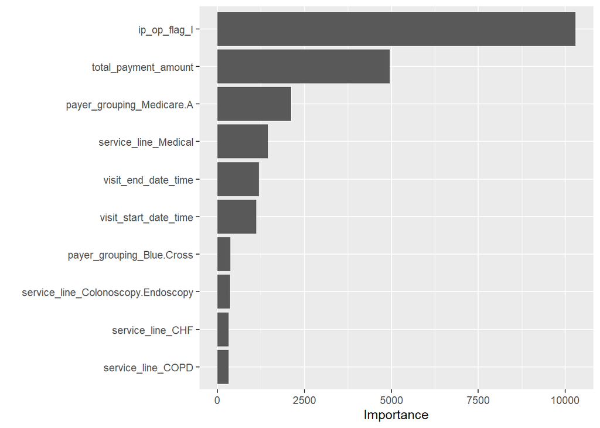

```r
last_fit_rf %>%
  pluck(".workflow", 1) %>%
  extract_fit_parsnip() %>%
  vip(num_features = 10)
```

Take a look at the confusion matrix:

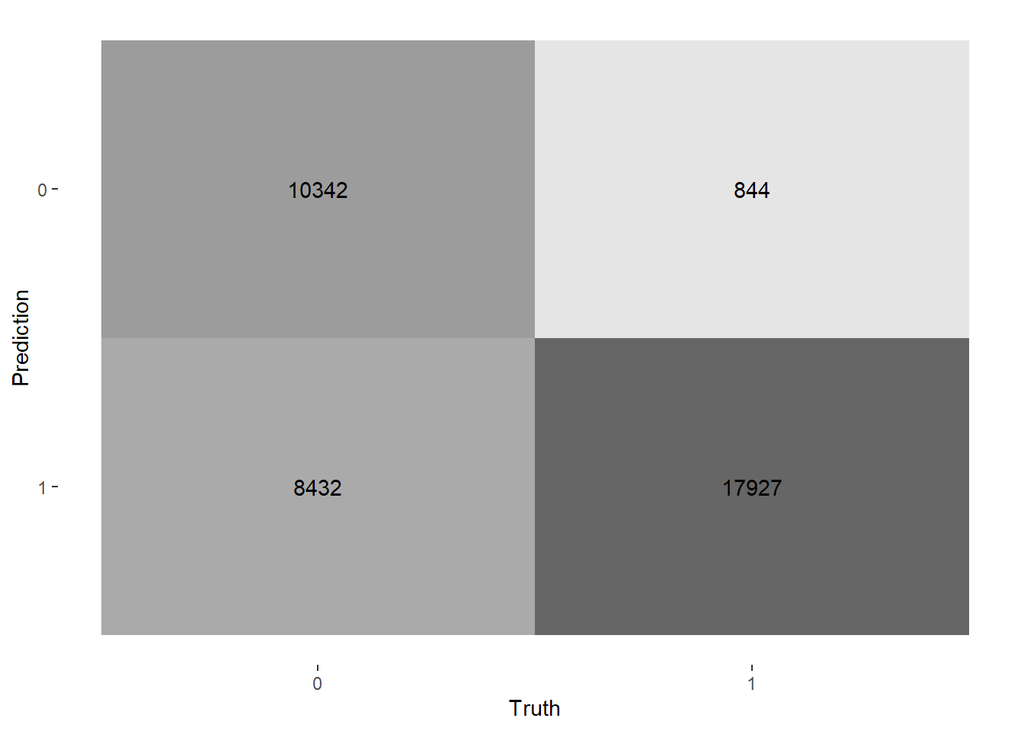

```r
last_fit_rf %>%
  collect_predictions() %>%
  conf_mat(denial_flag, .pred_class) %>%
  autoplot(type = "heatmap")
```

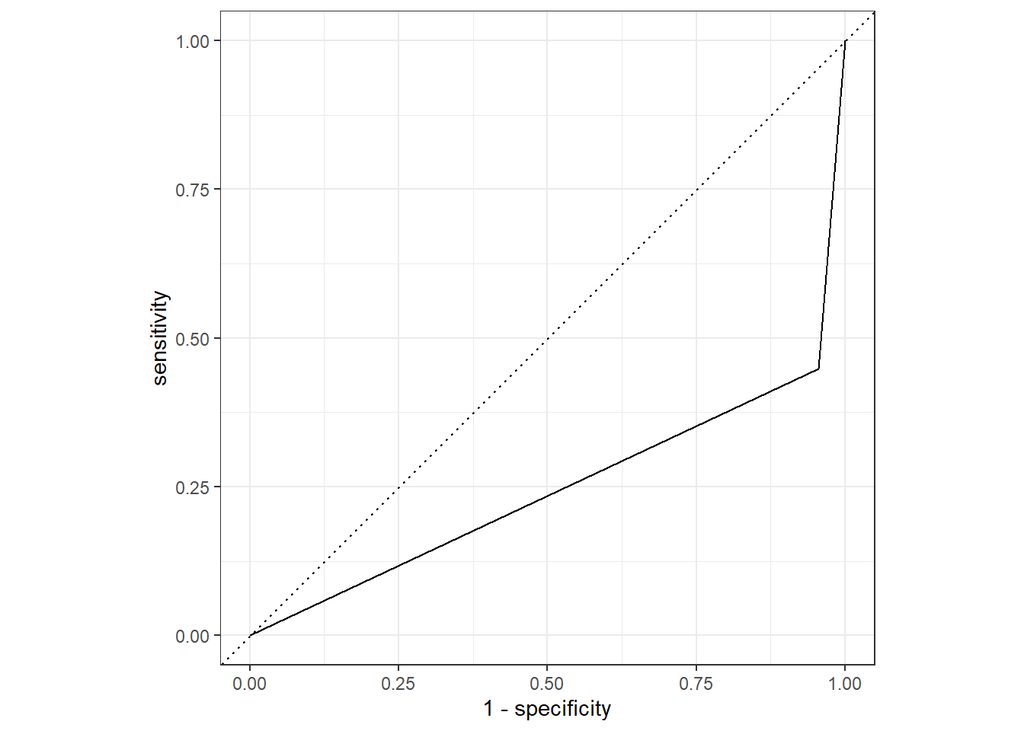

```r
last_fit_rf %>%
  collect_predictions() %>%
  mutate(.pred_class = as.integer(.pred_class)) %>%
  roc_curve(denial_flag, .pred_class) %>%
  autoplot()
```